# Factor Estimate Limit Behaviors

GOAL

The goal of this [R Markdown](http://rmarkdown.rstudio.com) Notebook is to demonstrate the various Limit Behaviors available in Factor Estimates.

DEFINITIONS

First of all, let’s define our terms:

Support (Probability Distributions): “In probability theory, the support of a probability distribution can be loosely thought of as the closure of the set of possible values of a random variable having that distribution.” https://en.wikipedia.org/wiki/Support_(mathematics)

Factor Estimate: In the context of the grctoolkit package, a Factor Estimate is a configurable estimate of a risk factor.

Limit: Here, limit is taken in its plain meaning (i.e. not to be confused with a mathematical limit). “a prescribed maximum or minimum amount, quantity, or number” https://www.merriam-webster.com/dictionary/limit

EXPLANATION

When estimating a risk factor, we typically use a probability distribution. To keep this tutorial simple, we will use here the well-known normal distribution to represent the potential impact of a risk factor. In this simplistic scenario, we consider a typical loss of 100 with a standard deviation of 10.

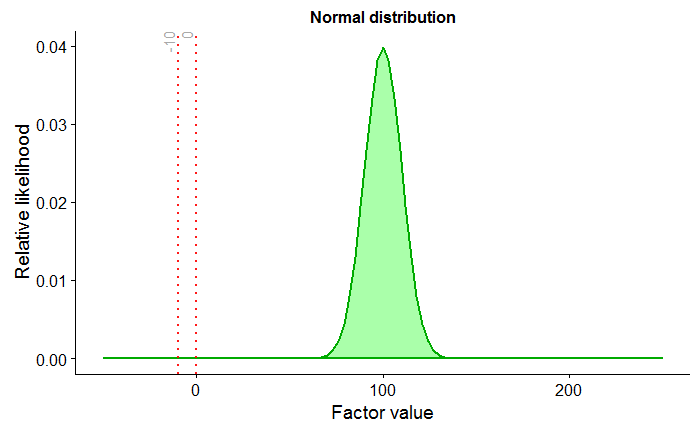

```r
library(grctoolkit)
require(ggplot2, grctoolkit)
fun <- function(x, ...) { return(dnorm(x = x, mean = 100, sd = 10, log = FALSE))  }
plot_addition <- overplot_vertical_lines(x_values = c(-10,0), x_labels = c(-10, 0), color = "red", line_type = "dotted")
plot_probability_density_function(title = "Normal distribution", fun = fun, x_start = -50, x_end = 250, plot_addition = plot_addition)
```

This is all very nice.

Now let’s have a look between the two dotted red lines in the range between -10 and 0. At first glance, it looks like it’s all 0s.

But to better understand the shape of our normal distribution, let’s zoom into that range and see how it looks like:

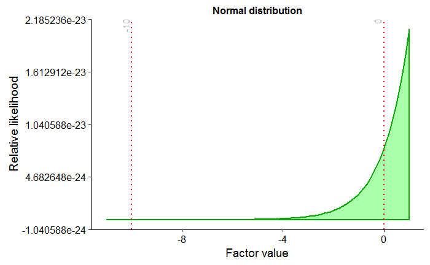

```r
fun <- function(x, ...) { return(dnorm(x = x, mean = 100, sd = 10, log = FALSE))  }
plot_addition <- overplot_vertical_lines(x_values = c(-10,0), x_labels = c(-10, 0), color = "red", line_type = "dotted")
plot_probability_density_function(title = "Normal distribution", fun = fun, x_start = -11, x_end = 1, plot_addition = plot_addition)
```

Do you see?

TUTORIAL

First of all, let’s load the grctoolkit package.

```r
require(grctoolkit)
```